# Reproducible Research: Peer Assessment 1

## Loading and preprocessing the data

Reading in the .csv file and creating a new dates format to be used when finding the total steps per day:

```r
#1 Code to Read in the Data:
activity_data=read.csv("activity.csv")
dates=c(paste0("10/",1:31,"/2012"),paste0("11/",1:30,"/2012"))

#2 calculate the total number of steps per day and make a histogram
total=NULL
for (i in 1:length(dates)) {
  total[i]=with(activity_data, sum(steps[date == dates[i]]),na.rm=TRUE)
}
#Dataframe for total steps taken per day
tot_steps <- data.frame(dates,total)
names(tot_steps) <- c("date","total # of Steps")
head(tot_steps)
```

```
##        date total # of Steps
## 1 10/1/2012               NA
## 2 10/2/2012              126
## 3 10/3/2012            11352
## 4 10/4/2012            12116
## 5 10/5/2012            13294
## 6 10/6/2012            15420
```

## What is mean total number of steps taken per day?

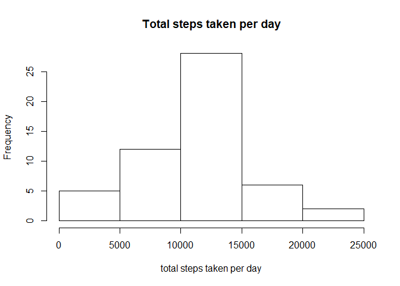

```r
#make a histogram of the total number of steps taken per day
hist(tot_steps$`total # of Steps`,xlab="total steps taken per day",main="Total steps taken per day")
```

```r
#3 Calculate the Mean and Median number of steps in a day
AvG_day=mean(tot_steps$`total # of Steps`,na.rm=TRUE)
Med_day=median(tot_steps$`total # of Steps`,na.rm=TRUE)
data.frame(AvG_day,Med_day)
```

```
##    AvG_day Med_day
## 1 10766.19   10765
```

## What is the average daily activity pattern?

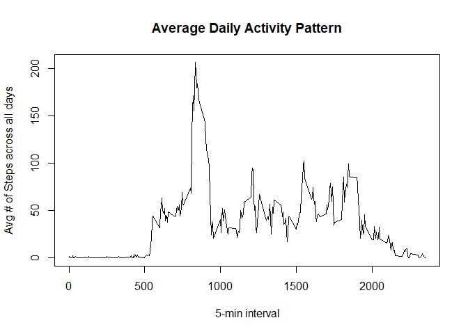

```r
#4 Create a time series plot of average number of steps in each 5-min interval averaged over all days
library(plyr)
interval_steps=ddply(activity_data, "interval", summarise, avg_steps = mean(steps,na.rm=TRUE))
plot(interval_steps$interval,interval_steps$avg_steps,type="l",xlab="5-min interval",ylab="Avg # of Steps across all days",
     main="Average Daily Activity Pattern")
```

```r
#5locate the interval that has the maximum number of steps
max_interval=interval_steps$interval[which.max(interval_steps$avg_steps)]
```

The maximum number of steps occurs during the following 5-minute interal:

```r
max_interval
```

```
## [1] 835
```

## Imputing missing values

The strategy used to handle missing values in the dataset was to replace a particular NA value with the average number of steps over the 2 month period for the corresponding 5 minute interval. For example if 10/1/2012 was “NA” for interval 250, it would be replaced with the average number of steps for interval 250 taken from the available data.

First, of the 17568 possible data points between 10/1/2012 and 11/30/2012, let’s see how many are missing:

```r
#6 Code to impute missing values
#determine the total number of missing values
total_NA=sum(is.na(activity_data$steps))
total_NA
```

```
## [1] 2304
```

```r
#imputing data to replace NA values with the 2 month average for that particular time interval
#creating a new data set with the missing data filled in that is same size of the original data set
activity_data_new=activity_data
for (i in 1:nrow(activity_data_new)){
  if (is.na(activity_data_new[i,1])){
    activity_data_new[i,1]=interval_steps$avg_steps[interval_steps$interval == activity_data_new[i,3]]
  }
}
#calculate the total number of steps per day for new data frame containing imputed values
total_new=NULL
for (i in 1:length(dates)) {
  total_new[i]=with(activity_data_new, sum(steps[date == dates[i]]),na.rm=TRUE)
}

# Build Dataframe for total steps taken per day
tot_steps_new <- data.frame(dates,total_new)
names(tot_steps_new) <- c("date","total # of Steps")
```

Now, looking at the new dataframe containing the total steps taken per day we see that 10/1/2012 is changed from NA to a value based on the 2 month average:

```r
head(tot_steps_new)
```

```
##        date total # of Steps
## 1 10/1/2012         10766.19
## 2 10/2/2012           126.00
## 3 10/3/2012         11352.00
## 4 10/4/2012         12116.00
## 5 10/5/2012         13294.00
## 6 10/6/2012         15420.00
```

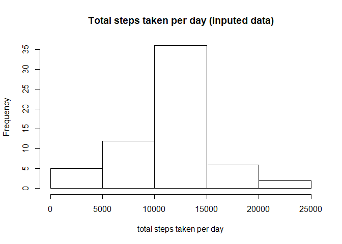

```r
#make a histogram of the total number of steps taken per day of the data frame containing imputed values
hist(tot_steps_new$`total # of Steps`,xlab="total steps taken per day",main="Total steps taken per day (inputed data)")
```

```r
#Calculate the Mean and Median number of steps in a day of the new data frame
AvG_day_new=mean(tot_steps_new$`total # of Steps`,na.rm=TRUE)
Med_day_new=median(tot_steps_new$`total # of Steps`,na.rm=TRUE)
```

We can now compare the calculations based off of the original data to the values of the dataset with imputed data:

```r
#Compare New and Old Values
Differences=data.frame(AvG_day,AvG_day_new,Med_day,Med_day_new)
Differences
```

```
##    AvG_day AvG_day_new Med_day Med_day_new
## 1 10766.19    10766.19   10765    10766.19
```

## Are there differences in activity patterns between weekdays and weekends?

In this section we will add a column to the dataframe that labels the date as either “weekday” or “weekend”, subset the data based on if the particular date falls on a weekday or weekend day and perform the same calculations as above to determine if this has any influence on the activity levels.

```r
#Add a column to the imputed dataframe "Weekday" and "weekend"
activity_data_new_days=activity_data_new
activity_data_new_days$ddate <- strftime(strptime(activity_data_new_days$date,"%m/%d/%Y"),"%Y-%m-%d")
activity_data_new_days$day <- weekdays(as.Date(activity_data_new_days$ddate))

for (i in 1:nrow(activity_data_new_days)){
  if (activity_data_new_days[i,5] %in% c('Saturday','Sunday')){
    activity_data_new_days[i,5]='weekend'}
    else{
      activity_data_new_days[i,5]= 'weekday'
      }
}
head(activity_data_new_days)
```

```
##       steps      date interval      ddate     day
## 1 1.7169811 10/1/2012        0 2012-10-01 weekday
## 2 0.3396226 10/1/2012        5 2012-10-01 weekday
## 3 0.1320755 10/1/2012       10 2012-10-01 weekday
## 4 0.1509434 10/1/2012       15 2012-10-01 weekday
## 5 0.0754717 10/1/2012       20 2012-10-01 weekday
## 6 2.0943396 10/1/2012       25 2012-10-01 weekday
```

Finally we will create a time series plot again to show differences between the weekday and weekend activity as shown below:

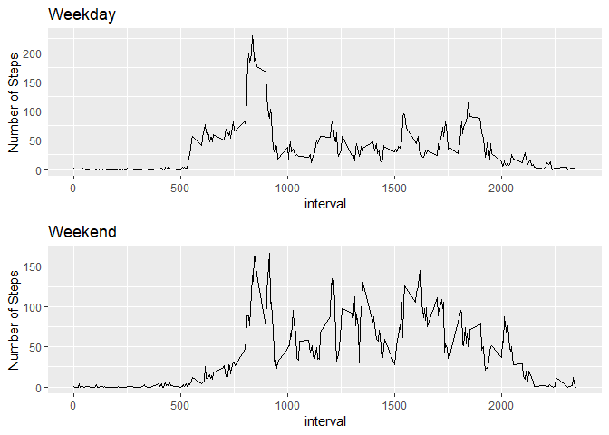

```r
#8 Create a time series plot of average number of steps in each 5-min interval averaged over all days
weekend_steps = subset(activity_data_new_days, day == "weekend")
weekday_steps = subset(activity_data_new_days, day == "weekday")

interval_steps_weekend=ddply(weekend_steps, "interval", summarise, avg_steps = mean(steps,na.rm=TRUE))
interval_steps_weekday=ddply(weekday_steps, "interval", summarise, avg_steps = mean(steps,na.rm=TRUE))
library(ggplot2)
library(gridExtra)
require(gridExtra)
plot3_1 <- ggplot(interval_steps_weekday, aes(interval,avg_steps)) + geom_line()+ylab("Number of Steps")+labs(title= "Weekday")
plot3_2 <- ggplot(interval_steps_weekend, aes(interval,avg_steps)) + geom_line()+ylab("Number of Steps")+labs(title= "Weekend")
grid.arrange(plot3_1, plot3_2, ncol=1)
```